# Children at Risk: Poverty, Disease & the Global Development Gap

## 🚀 Chart 6: Which Countries Made the Most Progress?

Not all starting points are equal — but progress is always possible. This **lollipop chart** ranks the top 20 countries by their **absolute improvement in zinc coverage** from their first recorded measurement to their most recent one. Countries that regressed are shown in red.

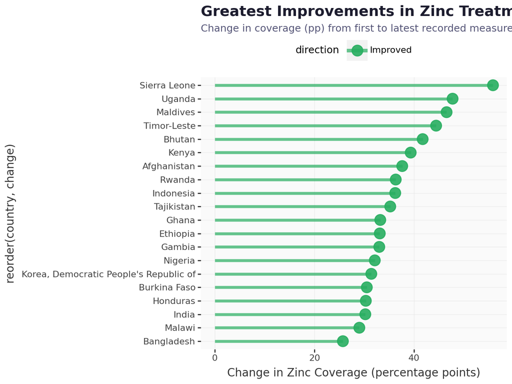

```python
# Compute first and latest zinc rate per country, then calculate change
progress = (
    ind2
    .filter(pl.col("sex") == "Total")
    .group_by(["country", "alpha_3_code"])
    .agg([
        pl.col("obs_value").sort_by("time_period").first().alias("first_val"),
        pl.col("obs_value").sort_by("time_period").last().alias("last_val"),
        pl.col("time_period").min().alias("first_yr"),
        pl.col("time_period").max().alias("last_yr"),
        pl.col("time_period").n_unique().alias("n_yrs")
    ])
    .filter(pl.col("n_yrs") >= 2)
    .with_columns(
        (pl.col("last_val") - pl.col("first_val")).alias("change")
    )
    # Label direction using pl.when for axis colouring
    .with_columns(
        pl.when(pl.col("change") >= 0)
          .then(pl.lit("Improved"))
          .otherwise(pl.lit("Declined"))
          .alias("direction")
    )
    .sort("change", descending=True)
    .head(20)
    .to_pandas()
)

p = (
    ggplot(progress, aes(y="reorder(country, change)", x="change", color="direction"))
    + geom_segment(
        aes(x=0, xend="change", yend="reorder(country, change)"),
        size=1.5, alpha=0.7
    )
    + geom_point(size=5, alpha=0.9)
    + scale_color_manual(
        values={"Improved": "#27ae60", "Declined": "#e74c3c"},
        name=None
    )
    + theme_report()
    + theme(legend_position="top")
    + labs(
        title    = "Greatest Improvements in Zinc Treatment Coverage",
        subtitle = "Change in coverage (pp) from first to latest recorded measurement  |  Top 20 countries",
        x        = "Change in Zinc Coverage (percentage points)",
        y        = None
    )
)
ipy_display(p)
```

**Sierra Leone’s +55.8 pp improvement** is unmatched globally — rising from just 2% in 2005 to 57.8% in 2019. **Uganda (+47.7 pp)** and **Maldives (+46.5 pp)** follow closely. Crucially, these are not wealthy nations — they are low- and lower-middle-income countries that made a deliberate national choice to invest in child health infrastructure. Their trajectories are a blueprint for others.

## 📦 Chart 7: Coverage Distribution by Income Group

Does wealth reliably predict zinc coverage? This **boxplot with individual data points** shows the distribution of zinc treatment rates within each World Bank income group — revealing that **low-income countries show the widest spread**, from near-zero to world-leading rates.

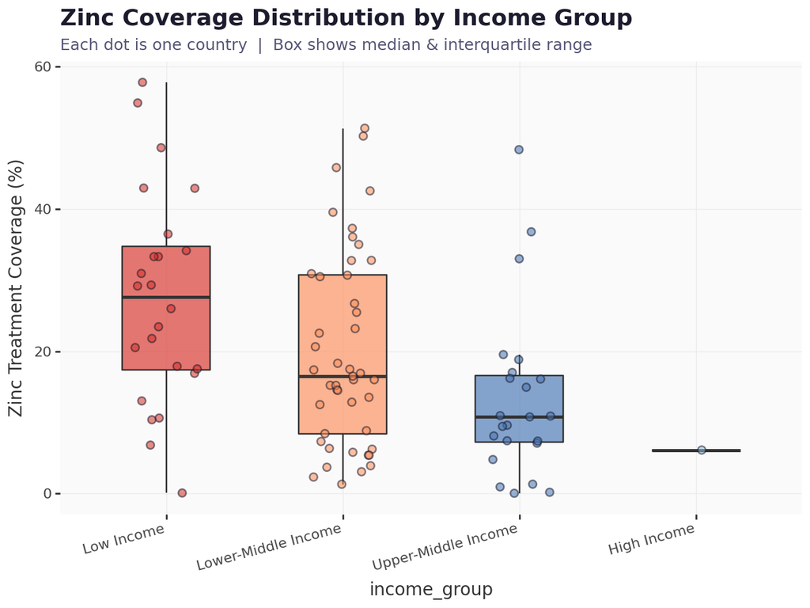

```python
# Reuse income_group from gdp_avg (already computed in scatter section)
box_data = zinc_latest.join(gdp_avg, on="alpha_3_code", how="inner").to_pandas()

# Set ordered categorical so x-axis respects income hierarchy
import pandas as pd
box_data["income_group"] = pd.Categorical(
    box_data["income_group"],
    categories=["Low Income", "Lower-Middle Income", "Upper-Middle Income", "High Income"],
    ordered=True
)
box_data = box_data.sort_values("income_group")

income_fill = {
    "Low Income":           "#d73027",
    "Lower-Middle Income":  "#fc8d59",
    "Upper-Middle Income":  "#4575b4",
    "High Income":          "#91bfdb"
}

p = (
    ggplot(box_data, aes(x="income_group", y="zinc_rate", fill="income_group"))
    + geom_boxplot(alpha=0.65, width=0.5, outlier_alpha=0)
    + geom_jitter(width=0.18, alpha=0.55, size=2, color="#1c1c2e")
    + scale_fill_manual(values=income_fill, name=None)
    + theme_report()
    + theme(
        legend_position = "none",
        axis_text_x     = element_text(angle=15, ha="right")
    )
    + labs(
        title    = "Zinc Coverage Distribution by Income Group",
        subtitle = "Each dot is one country  |  Box shows median & interquartile range",
        x        = None,
        y        = "Zinc Treatment Coverage (%)"
    )
)
ipy_display(p)
```

The boxplot delivers a counter-intuitive result: **Low Income countries have the highest median zinc coverage** among the four groups — and several of their outliers sit above 40%. Upper-Middle Income countries cluster near the bottom. This decoupling of income from health access suggests that **low-income countries which do invest** can achieve remarkable outcomes, but without that investment, wealth alone is no guarantee.